# REI Meta-Analysis

Ryan Stanley Falck

2023-01-24

# 1) Loading packages for meta-analysis

This step uses the r package “pacman” to load the packages which will be used throughout the analyses

```r
if (!require("pacman")) install.packages("pacman")
pacman::p_load(readxl, plyr, robumeta,metafor,clubSandwich,tidyverse)
detach("package:dplyr", unload = TRUE)
```

# 2) Importing data and preparing for analysis

This step imports the data sheet and then prepares all data for the analysis

```r
meta_data <- read_excel("META-ANALYSIS-23-January-2023.xlsx")
spaceless <- function(x) {colnames(x) <- gsub(" ", "_", colnames(x));x}
meta_data_spaceless <- spaceless(meta_data)

subset<-meta_data_spaceless[c(1:45)]


subset.v2<-rename(subset,c("Parent_Study=1;_Secondary=2" = "Secondary_Study",
                                        "Outcome_Type_Broad_Domain" = "Outcome_Domain",
                                        "Expected_Direction_of_Change" = "Direction",
                                        "Total_Sample_Size" = "Sample_Size",
                                        "%Female" = "Female_pcnt",
                                        "Mobility_Status_(Healthy,_Frail,_Mobility_Impaired,_Mixed)" = "Mobility_Status",
                                        "Cognitive_Status_(Healthy,_Probable_MCI,_Neurological_Disease)" = "Cognitive_Status",
                                        "Intervention_Mode__(REI;_RT)...15" = "INT_1_Mode",
                                        "Intervention_Group_1_Size" = "INT_1_N",
                                        "Intervention_Mode__(REI;_RT)...17" = "INT_2_Mode",
                                        "Intervention\r\nGroup_2_Size" = "INT_2_N",
                                        "Control_Group_(BAT;_Waitlist;_Health_Education;_Other)" = "CNT_Mode",
                                        "Control_Group_Size" = "CNT_N",
                                        "Intervention_Length__(weeks)" = "Duration",
                                        "Intervention_Session_Duration__(min)" = "Session_Length",
                                        "Intervention_REI_Duration_(reps)" = "REI_reps",
                                        "Intervention_Exercise_Frequency__(days/week)" = "Session_Frequency",
                                        "Intervention_Frequency__(REI_sets)" = "REI_sets",
                                        "Intervention_Intensity_(Borg)" = "Intensity_borg",
                                        "Intervention_Intensity_(Omni)" = "Intensity_Omni",
                                        "Intervention_Intensity_(%RM)" = "Intensity_pcntRM",
                                        "Supervision_(yes/no)" = "Supervision",
                                        "Intervention_1_%Adherence" = "INT_1_Adherence",
                                        "Intervention_2_%Adherence" = "INT_2_Adherence",
                                        "Control_%Adherence" = "CNT_Adherence",
                                        "Intervention_1_Mean_Baseline" = "INT_1_Baseline_Mean",
                                        "Intervention_1_SD_Baseline" = "INT_1_Baseline_SD",
                                        "Intervention_1_Mean_Follow-Up" = "INT_1_Final_Mean",
                                        "Intervention_1_SD_Follow-up" = "INT_1_Final_SD",
                                        "Intervention_2_Mean_Baseline" = "INT_2_Baseline_Mean",
                                        "Intervention_2_SD_Baseline" = "INT_2_Baseline_SD",
                                        "Intervention_2_Mean_Follow-Up" = "INT_2_Final_Mean",
                                        "Intervention_2_SD_Follow-up" = "INT_2_Final_SD",
                                        "Control_Mean_Baseline" = "CNT_Baseline_Mean",
                                        "Control_SD_Baseline" = "CNT_Baseline_SD",
                                        "Control_Mean_Follow-up" = "CNT_Final_Mean",
                                        "Control_SD_Follow-up" = "CNT_Final_SD"))

library(dplyr)
subset.v3 <- subset.v2 %>%
  mutate(
    Secondary_Study = Secondary_Study - 1,
    CNT_Mode = case_when(
      CNT_Mode == "Stardard care" ~ "Usual Care",
      CNT_Mode == "Lifestyle maintenance" ~ "Usual Care",
      CNT_Mode == "Social and leisure activities" ~ "Active Control",
      CNT_Mode == "M-SRT" ~ "Active Control",
      CNT_Mode == "S-MRThip" ~ "Active Control",
      CNT_Mode == "Healthy education" ~ "Active Control"
    ),
    INT_1_Mode = case_when(
      INT_1_Mode == "F-URT" ~ "REI",
      INT_1_Mode == "I-FRT" ~ "REI",
      INT_1_Mode == "Suspension RT" ~ "REI",
      INT_1_Mode == "REI" ~ "REI"
    ),
    INT_2_Mode = case_when(
      INT_2_Mode == "M-URT" ~ "REI",
      INT_2_Mode == "S-MRT" ~ "RE",
      INT_2_Mode == "RE" ~ "RE",
      INT_2_Mode == "RT" ~ "RE"
    )
  )


subset.v4<- subset.v3[c(1:16,19:31,33:37,42:45)]
subset.v4<-rename(subset.v4,c("INT_Mode" = "INT_1_Mode",
                           "INT_N" = "INT_1_N",
                           "INT_Adherence" = "INT_1_Adherence",
                           "INT_Baseline_Mean" = "INT_1_Baseline_Mean",
                           "INT_Baseline_SD" = "INT_1_Baseline_SD",
                           "INT_Final_Mean" = "INT_1_Final_Mean",
                           "INT_Final_SD" = "INT_1_Final_SD"))

subset.v5<- subset.v3[c(1:14,17:30,32,33,38:45)]
subset.v5<-rename(subset.v5,c("INT_Mode" = "INT_2_Mode",
                              "INT_N" = "INT_2_N",
                              "INT_Adherence" = "INT_2_Adherence",
                              "INT_Baseline_Mean" = "INT_2_Baseline_Mean",
                              "INT_Baseline_SD" = "INT_2_Baseline_SD",
                              "INT_Final_Mean" = "INT_2_Final_Mean",
                              "INT_Final_SD" = "INT_2_Final_SD"))

subset.final<-rbind(subset.v4,subset.v5)
subset.final<-subset(subset.final, !is.na(INT_Mode))

subset.final <- subset.final %>%
  mutate_at(c('INT_Baseline_Mean','INT_Final_Mean','INT_Baseline_SD','INT_Final_SD','CNT_Baseline_Mean','CNT_Final_Mean','CNT_Baseline_SD','CNT_Final_SD'), as.numeric)

subset.final <- subset.final %>%
  mutate(
    INT_N = as.numeric(INT_N),
    SMD = ((INT_Final_Mean - INT_Baseline_Mean) - (CNT_Final_Mean - CNT_Baseline_Mean))/(sqrt((((INT_N - 1)*INT_Baseline_SD ^ 2) + ((CNT_N - 1)*CNT_Baseline_SD ^ 2))/(INT_N + CNT_N - 2))),
    SMD_2 = ifelse(Direction == "positive", SMD, -SMD),
    var.d = (((INT_N + CNT_N) / (INT_N * CNT_N)) + ((SMD_2^2) / (2*(INT_N + CNT_N)))),
    J = 1 - (3 / (4 * (INT_N + CNT_N - 2) - 1)),
    Hedge.g = SMD_2 * J,
    var.g = J^2 * var.d,
    se.g = sqrt(var.g /(INT_N + CNT_N)),
    LL.g = Hedge.g - se.g*1.96,
    UL.g = Hedge.g + se.g*1.96,
    sesqrd.ES = se.g^2
  )

subset.final$Forest_Author_Year <-paste(subset.final$Study, subset.final$Pub_Year)

REI <- subset(subset.final, INT_Mode =="REI")
RE <- subset(subset.final, INT_Mode == 'RE')

REI.phys<-subset(REI, Outcome_Type =="Physical Function")
REI.cog<-subset(REI, Outcome_Type =="Cognitive Function")
REI.falls<-subset(REI, Outcome_Type =="Fall Risk")
REI.QOL<-subset(REI, Outcome_Type =="Quality of Life")

RE.phys<-subset(RE, Outcome_Type =="Physical Function")
RE.cog<-subset(RE, Outcome_Type =="Cognitive Function")
RE.falls<-subset(RE, Outcome_Type =="Fall Risk")
RE.QOL<-subset(RE, Outcome_Type =="Quality of Life")
```

# 3) Meta-Analysis

For this step, I’ve conducted meta-analyses on each of the outcomes of interest separately (i.e., physical function, cognitive function, falls risk, and quality of life). Each analysis is using robust varience estimation (RVE) in order to account for heterogeneity. While this can account for heterogeneity in effect sizes, it does not solve possible issues of heterogeneity entirely.

```r
REI.phys.intonly<-robu(Hedge.g~1,var=var.g,studynum=ID,REI.phys) #Clustered at level of overall study
print(REI.phys.intonly)
```

```
## RVE: Correlated Effects Model with Small-Sample Corrections
##
## Model: Hedge.g ~ 1
##
## Number of studies = 11
## Number of outcomes = 103 (min = 3 , mean = 9.36 , median = 6 , max = 40 )
## Rho = 0.8
## I.sq = 70.32692
## Tau.sq = 0.2741941
##
##                Estimate StdErr t-value  dfs  P(|t|>) 95% CI.L 95% CI.U Sig
## 1 X.Intercept.    0.607  0.113    5.35 9.88 0.000337    0.354     0.86 ***
## ---
## Signif. codes: < .01 *** < .05 ** < .10 *
## ---
## Note: If df < 4, do not trust the results
```

```r
REI.cog.intonly<-robu(Hedge.g~1,var=var.g,studynum=ID,REI.cog) #Clustered at level of overall study
print(REI.cog.intonly)
```

```
## RVE: Correlated Effects Model with Small-Sample Corrections
##
## Model: Hedge.g ~ 1
##
## Number of studies = 5
## Number of outcomes = 26 (min = 1 , mean = 5.2 , median = 4 , max = 9 )
## Rho = 0.8
## I.sq = 61.7497
## Tau.sq = 0.2053016
##
##                Estimate StdErr t-value  dfs P(|t|>) 95% CI.L 95% CI.U Sig
## 1 X.Intercept.    0.672  0.213    3.16 3.94  0.0351    0.077     1.27  **
## ---
## Signif. codes: < .01 *** < .05 ** < .10 *
## ---
## Note: If df < 4, do not trust the results
```

Falls Risk (No significant effect)

```r
REI.falls.intonly<-robu(Hedge.g~1,var=var.g,studynum=ID,REI.falls) #Clustered at level of overall study
print(REI.falls.intonly)
```

```
## RVE: Correlated Effects Model with Small-Sample Corrections
##
## Model: Hedge.g ~ 1
##
## Number of studies = 4
## Number of outcomes = 5 (min = 1 , mean = 1.25 , median = 1 , max = 2 )
## Rho = 0.8
## I.sq = 30.31281
## Tau.sq = 0.04511344
##
##                Estimate StdErr t-value  dfs P(|t|>) 95% CI.L 95% CI.U Sig
## 1 X.Intercept.    0.289  0.187    1.54 2.89   0.224    -0.32    0.897
## ---
## Signif. codes: < .01 *** < .05 ** < .10 *
## ---
## Note: If df < 4, do not trust the results
```

Quality of Life (No significant effect)

```r
REI.QoL.intonly<-robu(Hedge.g~1,var=var.g,studynum=ID,REI.QOL) #Clustered at level of overall study
print(REI.QoL.intonly)
```

```
## RVE: Correlated Effects Model with Small-Sample Corrections
##
## Model: Hedge.g ~ 1
##
## Number of studies = 3
## Number of outcomes = 3 (min = 1 , mean = 1 , median = 1 , max = 1 )
## Rho = 0.8
## I.sq = 39.82386
## Tau.sq = 0.0906419
##
##                Estimate StdErr t-value dfs P(|t|>) 95% CI.L 95% CI.U Sig
## 1 X.Intercept.    0.919  0.274    3.35   2  0.0788   -0.263      2.1   *
## ---
## Signif. codes: < .01 *** < .05 ** < .10 *
## ---
## Note: If df < 4, do not trust the results
```

# 4) Sensitivity Analyses

I’ve also conducted sensitivity analyses for the meta-effects shown. The sensitivity analyses examine whether the effects estimated differ based on the correlation between effect sizes of th same study (i.e., if there is high correlation, then for Study A all effect sizes are large; for Study B, all effect sizes are small, etc.). The results for each of these do not suggest that the correlation between effect sizes substantially altered the meta-effects estimated.

Physical Function Sensitivity Analysis

```r
sensitivity(REI.phys.intonly)
```

```
## RVE: Correlated Effects Model with Small-Sample Corrections
## Model: Hedge.g ~ 1
##
## Sensitivity Analysis
##
##                           Rho = 0 Rho = 0.2 Rho = 0.4 Rho = 0.6 Rho = 0.8
##  X.Intercept. Coefficient 0.606   0.606     0.606     0.607     0.607
##               Std. Error  0.113   0.113     0.113     0.113     0.113
##  Tau.sq       Estimate    0.267   0.269     0.270     0.272     0.274
##  Rho = 1
##  0.607
##  0.113
##  0.276
```

Cognitive Function Sensitivity Analysis

```r
sensitivity(REI.cog.intonly)
```

```
## RVE: Correlated Effects Model with Small-Sample Corrections
## Model: Hedge.g ~ 1
##
## Sensitivity Analysis
##
##                           Rho = 0 Rho = 0.2 Rho = 0.4 Rho = 0.6 Rho = 0.8
##  X.Intercept. Coefficient 0.669   0.670     0.671     0.671     0.672
##               Std. Error  0.212   0.212     0.212     0.213     0.213
##  Tau.sq       Estimate    0.188   0.192     0.197     0.201     0.205
##  Rho = 1
##  0.672
##  0.213
##  0.210
```

Falls Risk Sensitivity Analysis

```r
sensitivity(REI.falls.intonly)
```

```
## RVE: Correlated Effects Model with Small-Sample Corrections
## Model: Hedge.g ~ 1
##
## Sensitivity Analysis
##
##                           Rho = 0 Rho = 0.2 Rho = 0.4 Rho = 0.6 Rho = 0.8
##  X.Intercept. Coefficient 0.2873  0.2876    0.2879    0.288     0.2885
##               Std. Error  0.1865  0.1867    0.1868    0.187     0.1870
##  Tau.sq       Estimate    0.0407  0.0418    0.0429    0.044     0.0451
##  Rho = 1
##  0.2889
##  0.1871
##  0.0462
```

Quality of Life Sensitivity Analysis

```r
sensitivity(REI.QoL.intonly)
```

```
## RVE: Correlated Effects Model with Small-Sample Corrections
## Model: Hedge.g ~ 1
##
## Sensitivity Analysis
##
##                           Rho = 0 Rho = 0.2 Rho = 0.4 Rho = 0.6 Rho = 0.8
##  X.Intercept. Coefficient 0.9189  0.9189    0.9189    0.9189    0.9189
##               Std. Error  0.2743  0.2743    0.2743    0.2743    0.2743
##  Tau.sq       Estimate    0.0906  0.0906    0.0906    0.0906    0.0906
##  Rho = 1
##  0.9189
##  0.2743
##  0.0906
```

# 5) Forest Plots

Here is the code for the forest plots. I have attached each of the graphs separately so that you can review in detail.

Physical Function

```r
forest.REI.phys<-subset(REI.phys, select = c(ID,Forest_Author_Year,Hedge.g,LL.g,UL.g))
forest.REI.phys<-forest.REI.phys[order(forest.REI.phys$ID),]
Overall.effect <-c(NA, "Overall Effect", 0.610, 0.350, 0.860)
forest.REI.phys<-rbind(forest.REI.phys,Overall.effect)
forest.REI.phys$ES<- rev(c(1:105))
forest.REI.phys <- forest.REI.phys %>%
  mutate_at(c('Hedge.g','LL.g','UL.g'), as.numeric)

forest.REI.phys.plot <- ggplot(forest.REI.phys, aes(y= ES, x = Hedge.g, xmin = LL.g, xmax= UL.g)) + geom_point() + geom_errorbarh(height=.1) +
  scale_y_continuous(name= "Author & Year", breaks=rev(1:nrow(forest.REI.phys)), labels=forest.REI.phys$Forest_Author_Year) +
  scale_x_continuous(name="Hedge's g Effect Size", limits = c(-3,3), breaks = c(-3, 0, 3)) +
  labs(title="Physical Function Forest Plot") +
  geom_vline(xintercept=0, color="black", linetype="dashed", alpha=.5) + theme_classic()
```

Cognitive Function

```r
forest.REI.cog<-subset(REI.cog, select = c(ID,Forest_Author_Year,Hedge.g,LL.g,UL.g))
forest.REI.cog<-forest.REI.cog[order(forest.REI.cog$ID),]
Overall.effect <-c(NA, "Overall Effect", 0.670, 0.080, 1.270)
forest.REI.cog<-rbind(forest.REI.cog,Overall.effect)
forest.REI.cog$ES<- rev(c(1:27))
forest.REI.cog <- forest.REI.cog %>%
  mutate_at(c('Hedge.g','LL.g','UL.g'), as.numeric)

forest.REI.cog.plot <- ggplot(forest.REI.cog, aes(y= ES, x = Hedge.g, xmin = LL.g, xmax= UL.g)) + geom_point() + geom_errorbarh(height=.1) +
  scale_y_continuous(name= "Author & Year", breaks=rev(1:nrow(forest.REI.cog)), labels=forest.REI.cog$Forest_Author_Year) +
  scale_x_continuous(name="Hedge's g Effect Size", limits = c(-3,3), breaks = c(-3, 0, 3)) +
  labs(title="Cognitive Function Forest Plot") +
  geom_vline(xintercept=0, color="black", linetype="dashed", alpha=.5) + theme_classic()
```

Falls Risk

```r
forest.REI.falls<-subset(REI.falls, select = c(ID,Forest_Author_Year,Hedge.g,LL.g,UL.g))
forest.REI.falls<-forest.REI.falls[order(forest.REI.falls$ID),]
Overall.effect <-c(NA, "Overall Effect", 0.290, -0.320, 0.900)
forest.REI.falls<-rbind(forest.REI.falls,Overall.effect)
forest.REI.falls$ES<- rev(c(1:6))
forest.REI.falls <- forest.REI.falls %>%
  mutate_at(c('Hedge.g','LL.g','UL.g'), as.numeric)

forest.REI.falls.plot <- ggplot(forest.REI.falls, aes(y= ES, x = Hedge.g, xmin = LL.g, xmax= UL.g)) + geom_point() + geom_errorbarh(height=.1) +
  scale_y_continuous(name= "Author & Year", breaks=rev(1:nrow(forest.REI.falls)), labels=forest.REI.falls$Forest_Author_Year) +
  scale_x_continuous(name="Hedge's g Effect Size", limits = c(-1,1), breaks = c(-1, 0, 1)) +
  labs(title="Falls Risk Forest Plot") +
  geom_vline(xintercept=0, color="black", linetype="dashed", alpha=.5) + theme_classic()
```

Quality of Life

```r
forest.REI.QOL<-subset(REI.QOL, select = c(ID,Forest_Author_Year,Hedge.g,LL.g,UL.g))
forest.REI.QOL<-forest.REI.QOL[order(forest.REI.falls$ID),]
Overall.effect <-c(NA, "Overall Effect", 0.920, -0.260, 2.100)
forest.REI.QOL<-rbind(forest.REI.QOL,Overall.effect)
forest.REI.QOL<- forest.REI.QOL[-c(1,5,6),]
forest.REI.QOL$ES<- rev(c(1:4))
forest.REI.QOL <- forest.REI.QOL %>%
  mutate_at(c('Hedge.g','LL.g','UL.g'), as.numeric)

forest.REI.QOL.plot <- ggplot(forest.REI.QOL, aes(y= ES, x = Hedge.g, xmin = LL.g, xmax= UL.g)) + geom_point() + geom_errorbarh(height=.1) +
  scale_y_continuous(name= "Author & Year", breaks=rev(1:nrow(forest.REI.QOL)), labels=forest.REI.QOL$Forest_Author_Year) +
  scale_x_continuous(name="Hedge's g Effect Size", limits = c(-3,3), breaks = c(-3, 0, 3)) +
  labs(title="Quality of Life Forest Plot") +
  geom_vline(xintercept=0, color="black", linetype="dashed", alpha=.5) + theme_classic()
```

# 6) Leave-One-Out Analysis

This analysis examines the extent that individual effect sizes influence the summary effect size and significance of the effect. I conducted a separate one for each outcome of interest.

Leave-one-out function

```r
leave.one.out <- function(rownum){

  # subset dataframe
  vec <- rep(TRUE, nrow(REI.phys))
  vec[rownum] <- FALSE
  inf <- subset(REI.phys, vec)

  # fit reference model
  rve.model.ref <- robu(Hedge.g~1,var=var.g,studynum=ID, data = REI.phys)

  # fit adjusted model
  rve.model <- robu(Hedge.g~1,var=var.g,studynum=ID, data = inf)

  # return results
  results.vec <- c(g.study = round(REI.phys$Hedge.g[rownum], 3),
                   g.adj = round(rve.model$reg_table$b.r, 3),
                   se.g.adj = round(rve.model$reg_table$SE, 3),
                   p.adj = round(rve.model$reg_table$prob, 5),
                   diff.g = round(rve.model$reg_table$b.r - rve.model.ref$reg_table$b.r, 3),
                   diff.se.g = round(rve.model$reg_table$SE - rve.model.ref$reg_table$SE, 3),
                   diff.p = round(rve.model$reg_table$prob - rve.model.ref$reg_table$prob, 5),
                   diff.isq = round(rve.model$mod_info$I.2 - rve.model.ref$mod_info$I.2, 3))
  return(results.vec)
}
```

Physical Function

```r
inf.phys <- sapply(1:nrow(REI.phys), leave.one.out)
inf.phys <- data.frame(t(inf.phys))
inf.phys <- data.frame(label = paste(REI.phys$Author_Year, REI.phys$Outcome, sep = " / "),
                       inf.phys)
inf.phys$z.g.study <- round(scale(inf.phys$g.study), 2)
inf.phys$g.min.sumeff.div.sdg <- round((REI.phys$Hedge.g - REI.phys.intonly$reg_table$b.r) / sd(REI.phys$Hedge.g), 2)

inf.phys
```

```
##                                                                    label
## 1                                               Cavalcante et al. / SPPB
## 2                                     Cavalcante et al. / 5 Chair Stands
## 3                                         Cavalcante et al. / Gait Speed
## 4                                    Cavalcante et al. / Timed Up and Go
## 5                                      Cavalcante et al. / 6 Minute Walk
## 6                Cavalcante et al. / Isokinetic Peak Torque (60 deg/sec)
## 7                                      Cavalcante et al. / Leg Press 1RM
## 8                                Chulvi-Medrano et al. / One-foot stance
## 9                                Chulvi-Medrano et al. / Timed Up and Go
## 10                                Chulvi-Medrano et al. / Tinetti’s test
## 11                            Eckardt / Isometric leg extension strength
## 12                                          Eckardt / Hand grip strength
## 13                                             Eckardt / Chair rise test
## 14                                      Eckardt / Chair rise test AIREX®
```

[output cut: 300 more lines]

Cognitive Function

```r
inf.cog <- sapply(1:nrow(REI.cog), leave.one.out)
inf.cog <- data.frame(t(inf.cog))
inf.cog <- data.frame(label = paste(REI.cog$Author_Year, REI.cog$Outcome, sep = " / "),
                      inf.cog)
inf.cog$z.g.study <- round(scale(inf.cog$g.study), 2)
inf.cog$g.min.sumeff.div.sdg <- round((REI.cog$Hedge.g - REI.cog.intonly$reg_table$b.r) / sd(REI.cog$Hedge.g), 2)

inf.cog
```

```
##                                                             label g.study g.adj
## 1  Cavalcante et al. / Composite Score: Global Cognitive Function   0.127 0.614
## 2  Cavalcante et al. / Composite Score: Global Executive Function  -0.819 0.627
## 3    Cavalcante et al. / Composite Score: Global Processing Speed   0.603 0.607
## 4                     Cavalcante et al. / Composite Score: Memory   0.844 0.603
## 5                                    Eckardt et al. / DSST Number   1.472 0.591
## 6                                      Eckardt et al. / DMT Score   0.168 0.614
## 7                                  Eckardt et al. / Stroop Circle   1.521 0.590
## 8                                 Eckardt et al. / Stroop Neutral   1.013 0.591
## 9                             Eckardt et al. / Stroop Incongruent   0.221 0.625
## 10                                         Eckardt et al. / Score   0.731 0.604
## 11                                         Eckardt et al. / TMT A   0.045 0.607
## 12                                         Eckardt et al. / TMT B  -0.025 0.607
## 13                                       Eckardt et al. / TMT B-A  -0.083 0.607
## 14                     Silva-Batista et al. / MoCA Visuoexecutive  -0.076 0.607
```

[output cut: 66 more lines]

Falls Risk

```r
inf.falls <- sapply(1:nrow(REI.falls), leave.one.out)
inf.falls <- data.frame(t(inf.falls))
inf.falls <- data.frame(label = paste(REI.falls$Author_Year, REI.falls$Outcome, sep = " / "),
                        inf.falls)
inf.falls$z.g.study <- round(scale(inf.falls$g.study), 2)
inf.falls$g.min.sumeff.div.sdg <- round((REI.falls$Hedge.g - REI.falls.intonly$reg_table$b.r) / sd(REI.falls$Hedge.g), 2)

inf.falls
```

```
##                                         label g.study g.adj se.g.adj   p.adj
## 1    Cavalcante et al. / Falls Efficacy Scale   0.127 0.614    0.113 0.00031
## 2              Eckardt / Falls Efficacy Scale  -0.819 0.627    0.115 0.00030
## 3        Piraua et al. / Falls Efficacy Scale   0.603 0.607    0.113 0.00034
## 4 Silva-Batista et al. / Falls Efficacy Scale   0.844 0.603    0.114 0.00036
## 5              Eckardt / Falls Efficacy Scale   1.472 0.591    0.115 0.00044
##   diff.g diff.se.g diff.p diff.isq z.g.study g.min.sumeff.div.sdg
## 1  0.007     0.000 -3e-05    0.504     -0.37                -1.28
## 2  0.021     0.002 -4e-05   -2.043     -1.48                 0.13
## 3  0.000     0.000  0e+00    0.774      0.18                 0.26
## 4 -0.004     0.000  2e-05    0.684      0.47                 1.53
## 5 -0.015     0.001  1e-04   -0.334      1.20                -0.04
```

Quality of Life

```r
inf.QOL <- sapply(1:nrow(REI.QOL), leave.one.out)
inf.QOL <- data.frame(t(inf.QOL))
inf.QOL <- data.frame(label = paste(REI.QOL$Author_Year, REI.QOL$Outcome, sep = " / "),
                      inf.QOL)
inf.QOL$z.g.study <- round(scale(inf.QOL$g.study), 2)
inf.QOL$g.min.sumeff.div.sdg <- round((REI.QOL$Hedge.g - REI.QoL.intonly$reg_table$b.r) / sd(REI.QOL$Hedge.g), 2)

inf.QOL
```

```
##                           label g.study g.adj se.g.adj   p.adj diff.g diff.se.g
## 1       Piraua et al. / WHOQofL   0.127 0.614    0.113 0.00031  0.007     0.000
## 2 Silva-Batista et al. / PDQ-39  -0.819 0.627    0.115 0.00030  0.021     0.002
## 3 Silva-Batista et al. / PDQ-39   0.603 0.607    0.113 0.00034  0.000     0.000
##   diff.p diff.isq z.g.study g.min.sumeff.div.sdg
## 1 -3e-05    0.504      0.22                 1.01
## 2 -4e-05   -2.043     -1.09                -0.98
## 3  0e+00    0.774      0.87                -0.10
```

# 7) Egger’s regression test for dependent effect sizes

Physical Function

```r
REI.phys.rve <- robu(Hedge.g~se.g, var.eff.size = var.g, studynum = ID, data = REI.phys)
print(REI.phys.rve)
```

```
## RVE: Correlated Effects Model with Small-Sample Corrections
##
## Model: Hedge.g ~ se.g
##
## Number of studies = 11
## Number of outcomes = 103 (min = 3 , mean = 9.36 , median = 6 , max = 40 )
## Rho = 0.8
## I.sq = 64.75144
## Tau.sq = 0.2252648
##
##                Estimate StdErr t-value  dfs P(|t|>) 95% CI.L 95% CI.U Sig
## 1 X.Intercept.   -0.298  0.335   -0.89 3.27  0.4342    -1.31    0.719
## 2         se.g   15.215  5.141    2.96 4.26  0.0384     1.28   29.149  **
## ---
## Signif. codes: < .01 *** < .05 ** < .10 *
## ---
## Note: If df < 4, do not trust the results
```

Cognitive Function

```r
REI.cog.rve <- robu(Hedge.g~se.g, var.eff.size = var.g, studynum = ID, data = REI.cog)
print(REI.cog.rve)
```

```
## RVE: Correlated Effects Model with Small-Sample Corrections
##
## Model: Hedge.g ~ se.g
##
## Number of studies = 5
## Number of outcomes = 26 (min = 1 , mean = 5.2 , median = 4 , max = 9 )
## Rho = 0.8
## I.sq = 29.21355
## Tau.sq = 0.05385206
##
##                Estimate StdErr t-value  dfs P(|t|>) 95% CI.L 95% CI.U Sig
## 1 X.Intercept.    -0.85  0.396   -2.15 2.26  0.1500    -2.38    0.677
## 2         se.g    24.75  6.227    3.97 2.30  0.0458     1.03   48.460  **
## ---
## Signif. codes: < .01 *** < .05 ** < .10 *
## ---
## Note: If df < 4, do not trust the results
```

Falls Risk

```r
REI.falls.rve <- robu(Hedge.g~se.g, var.eff.size = var.g, studynum = ID, data = REI.falls)
print(REI.falls.rve)
```

```
## RVE: Correlated Effects Model with Small-Sample Corrections
##
## Model: Hedge.g ~ se.g
##
## Number of studies = 4
## Number of outcomes = 5 (min = 1 , mean = 1.25 , median = 1 , max = 2 )
## Rho = 0.8
## I.sq = 1.324402
## Tau.sq = 0.001304921
##
##                Estimate StdErr t-value  dfs P(|t|>) 95% CI.L 95% CI.U Sig
## 1 X.Intercept.   -0.634  0.588   -1.08 1.49   0.425    -4.21     2.94
## 2         se.g   18.116  9.069    2.00 1.30   0.248   -50.33    86.56
## ---
## Signif. codes: < .01 *** < .05 ** < .10 *
## ---
## Note: If df < 4, do not trust the results
```

Quality of Life

```r
REI.QOL.rve <- robu(Hedge.g~se.g, var.eff.size = var.g, studynum = ID, data = REI.QOL)
print(REI.QOL.rve)
```

```
## RVE: Correlated Effects Model with Small-Sample Corrections
##
## Model: Hedge.g ~ se.g
##
## Number of studies = 3
## Number of outcomes = 3 (min = 1 , mean = 1 , median = 1 , max = 1 )
## Rho = 0.8
## I.sq = 0
## Tau.sq = 0
##
##                Estimate StdErr t-value dfs P(|t|>) 95% CI.L 95% CI.U Sig
## 1 X.Intercept.     4.43  0.946    4.68   1   0.134     -7.6     16.5
## 2         se.g   -53.41 14.354   -3.72   1   0.167   -235.8    129.0
## ---
## Signif. codes: < .01 *** < .05 ** < .10 *
## ---
## Note: If df < 4, do not trust the results
```

# 8) Funnel plots

Physical Function

```r
meta.res.REI.phys<-rma.mv(yi=Hedge.g,V=var.g,data=REI.phys,slab=Author_Year)
```

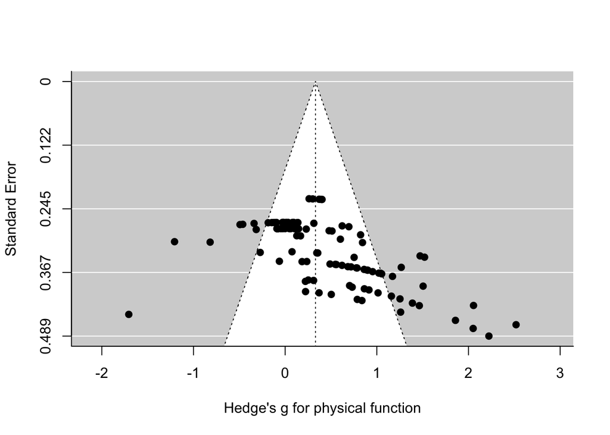

```r
funnel(meta.res.REI.phys, xlab = "Hedge's g for physical function")
```

Cognitive Function

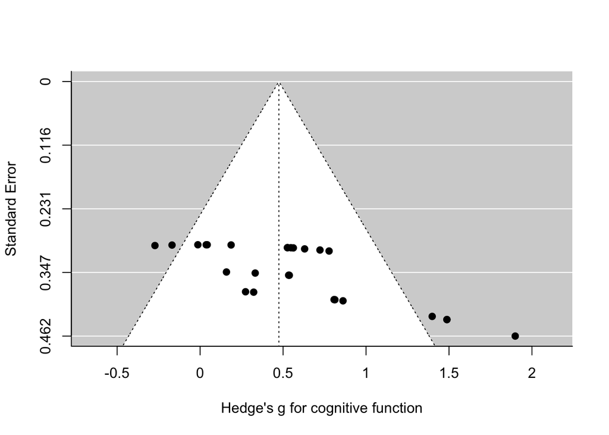

```r
meta.res.REI.cog<-rma.mv(yi=Hedge.g,V=var.g,data=REI.cog,slab=Author_Year)
funnel(meta.res.REI.cog, xlab = "Hedge's g for cognitive function")
```

Falls Risk

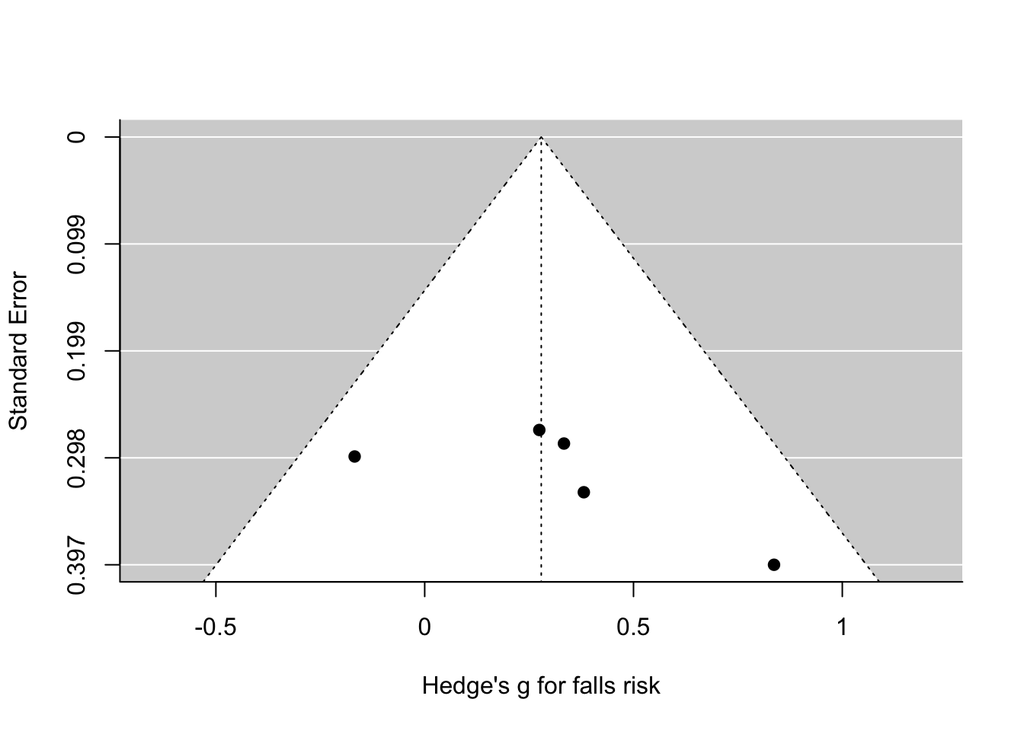

```r
meta.res.REI.falls<-rma.mv(yi=Hedge.g,V=var.g,data=REI.falls,slab=Author_Year)
funnel(meta.res.REI.falls, xlab = "Hedge's g for falls risk")
```

Quality of Life

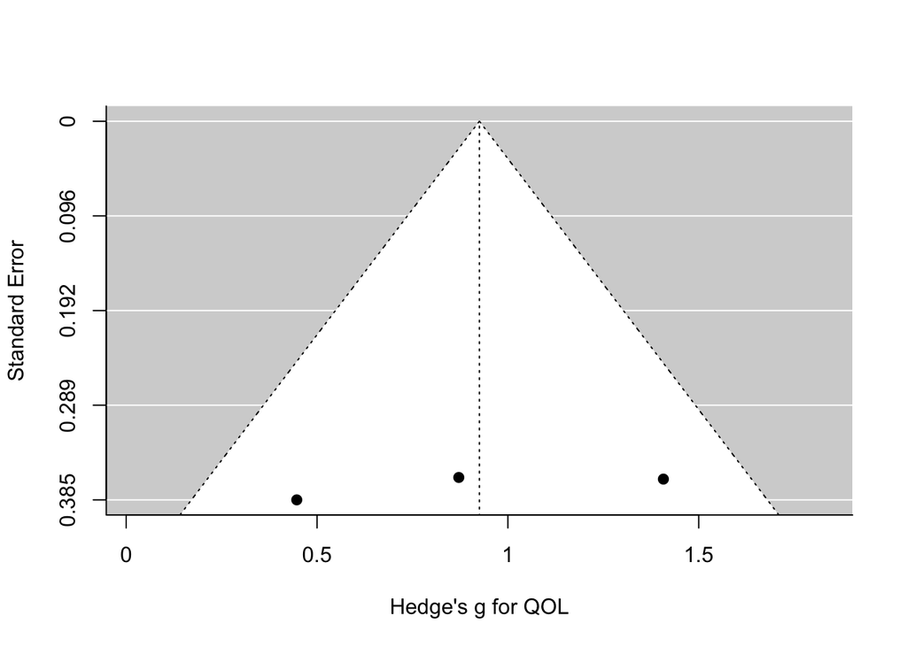

```r
meta.res.REI.QOL<-rma.mv(yi=Hedge.g,V=var.g,data=REI.QOL,slab=Author_Year)
funnel(meta.res.REI.QOL, xlab = "Hedge's g for QOL")
```

# 9) Precision Effect Estimation with Standard Error

Physical Function

```r
peese.rve.costs <- robu(Hedge.g~sesqrd.ES, var.eff.size = var.g, studynum = ID, data = REI.phys)
print(peese.rve.costs)
```

```
## RVE: Correlated Effects Model with Small-Sample Corrections
##
## Model: Hedge.g ~ sesqrd.ES
##
## Number of studies = 11
## Number of outcomes = 103 (min = 3 , mean = 9.36 , median = 6 , max = 40 )
## Rho = 0.8
## I.sq = 63.71646
## Tau.sq = 0.211151
##
##                Estimate StdErr t-value  dfs P(|t|>) 95% CI.L 95% CI.U Sig
## 1 X.Intercept.   0.0867  0.169   0.512 4.23  0.6342   -0.374    0.547
## 2    sesqrd.ES 133.0737 39.404   3.377 5.11  0.0191   32.432  233.716  **
## ---
## Signif. codes: < .01 *** < .05 ** < .10 *
## ---
## Note: If df < 4, do not trust the results
```

Cognitive Function

```r
peese.rve.costs <- robu(Hedge.g~sesqrd.ES, var.eff.size = var.g, studynum = ID, data = REI.cog)
print(peese.rve.costs)
```

```
## RVE: Correlated Effects Model with Small-Sample Corrections
##
## Model: Hedge.g ~ sesqrd.ES
##
## Number of studies = 5
## Number of outcomes = 26 (min = 1 , mean = 5.2 , median = 4 , max = 9 )
## Rho = 0.8
## I.sq = 21.46322
## Tau.sq = 0.03535076
##
##                Estimate StdErr t-value  dfs P(|t|>) 95% CI.L 95% CI.U Sig
## 1 X.Intercept.   -0.129  0.212  -0.609 2.04  0.6036    -1.02    0.767
## 2    sesqrd.ES  197.747 43.547   4.541 2.15  0.0394    22.48  373.015  **
## ---
## Signif. codes: < .01 *** < .05 ** < .10 *
## ---
## Note: If df < 4, do not trust the results
```

Falls Risk

```r
peese.rve.costs <- robu(Hedge.g~sesqrd.ES, var.eff.size = var.g, studynum = ID, data = REI.falls)
print(peese.rve.costs)
```

```
## RVE: Correlated Effects Model with Small-Sample Corrections
##
## Model: Hedge.g ~ sesqrd.ES
##
## Number of studies = 4
## Number of outcomes = 5 (min = 1 , mean = 1.25 , median = 1 , max = 2 )
## Rho = 0.8
## I.sq = 0
## Tau.sq = 0
##
##                Estimate StdErr t-value  dfs P(|t|>) 95% CI.L 95% CI.U Sig
## 1 X.Intercept.   -0.154  0.308    -0.5 1.68   0.675    -1.75     1.45
## 2    sesqrd.ES  159.140 61.117     2.6 1.28   0.187  -311.80   630.07
## ---
## Signif. codes: < .01 *** < .05 ** < .10 *
## ---
## Note: If df < 4, do not trust the results
```

Quality of Life

```r
peese.rve.costs <- robu(Hedge.g~sesqrd.ES, var.eff.size = var.g, studynum = ID, data = REI.QOL)
print(peese.rve.costs)
```

```
## RVE: Correlated Effects Model with Small-Sample Corrections
##
## Model: Hedge.g ~ sesqrd.ES
##
## Number of studies = 3
## Number of outcomes = 3 (min = 1 , mean = 1 , median = 1 , max = 1 )
## Rho = 0.8
## I.sq = 0
## Tau.sq = 0
##
##                Estimate  StdErr t-value dfs P(|t|>) 95% CI.L 95% CI.U Sig
## 1 X.Intercept.     2.64   0.532    4.95   1   0.127    -4.13      9.4
## 2    sesqrd.ES  -393.34 119.677   -3.29   1   0.188 -1913.97   1127.3
## ---
## Signif. codes: < .01 *** < .05 ** < .10 *
## ---
## Note: If df < 4, do not trust the results
```